# Lab_10_8977662

## **Lab 10 - Vanilla CNN and Fine-Tune VGG16 - for Dogs and Cats Classification**

### **Importing the Libraries**

```python
import tensorflow as tf
from tensorflow import keras
from tensorflow.keras import layers
import pathlib
from tensorflow.keras.utils import image_dataset_from_directory
import matplotlib.pyplot as plt
```

### **1. Obtain the Data**

```python
# This should point to the small dataset of the Kaggle Dogs vs Cats competition that was created in a previous notebook
data_folder = pathlib.Path('../ML_Framework/CSCN8010-Mycopy/data/kaggle_dogs_vs_cats_small')
```

```python
train_dataset = image_dataset_from_directory(
    data_folder / "train",
    image_size=(180, 180),
    batch_size=32)
validation_dataset = image_dataset_from_directory(
    data_folder / "validation",
    image_size=(180, 180),
    batch_size=32)
test_dataset = image_dataset_from_directory(
    data_folder / "test",
    image_size=(180, 180),
    batch_size=32)
```

```
Found 2000 files belonging to 2 classes.
Found 1000 files belonging to 2 classes.
Found 2000 files belonging to 2 classes.
```

```python
type(train_dataset)
```

```
tensorflow.python.data.ops.batch_op._BatchDataset
```

### **2. Exploratory Data Analysis**

**Displaying the shapes of the data and labels yielded by the `Dataset`**

```python
for data_batch, labels_batch in train_dataset:
    print("data batch shape:", data_batch.shape)
    print("labels batch shape:", labels_batch.shape)
    break
```

```
data batch shape: (32, 180, 180, 3)
labels batch shape: (32,)
```

- This (32, height, width, channels) represents the shape of the data batch, indicating that it contains 32 samples, each with the specified height = 180, width = 180, and number of channels = 3. Similarly, (32,) represents the shape of the labels batch, indicating that it contains 32 labels, one for each sample in the batch.

```python
labels_batch
```

```
<tf.Tensor: shape=(32,), dtype=int32, numpy=
array([0, 0, 0, 0, 0, 0, 1, 0, 0, 1, 1, 1, 0, 0, 0, 1, 0, 0, 1, 1, 0, 0,
       1, 1, 1, 1, 1, 0, 0, 1, 0, 0])>
```

- The batch contains 32 samples.
- Each sample is assigned a label.
- The labels are represented as integers. For example:
1. 0 might represent one class (e.g., "cat").
2. 1 might represent another class (e.g., "dog").
- Each element in the array corresponds to the label of a single sample in the batch.

```python
train_class_names = train_dataset.class_names
print(train_class_names)
```

```
['cat', 'dog']
```

- The training dataset contains two classes: 'cat' and 'dog'.

```
(-0.5, 179.5, 179.5, -0.5)
```

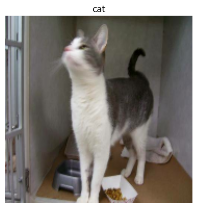

```python
# import imshow
import matplotlib.pyplot as plt

plt.imshow(data_batch[1].numpy().astype("uint8"))
plt.title(train_class_names[0])
plt.axis("off")
```

- The code displays the second image in the data batch.
- The title of the image is set to train_class_names[0], which corresponds to the class name 'cat'.

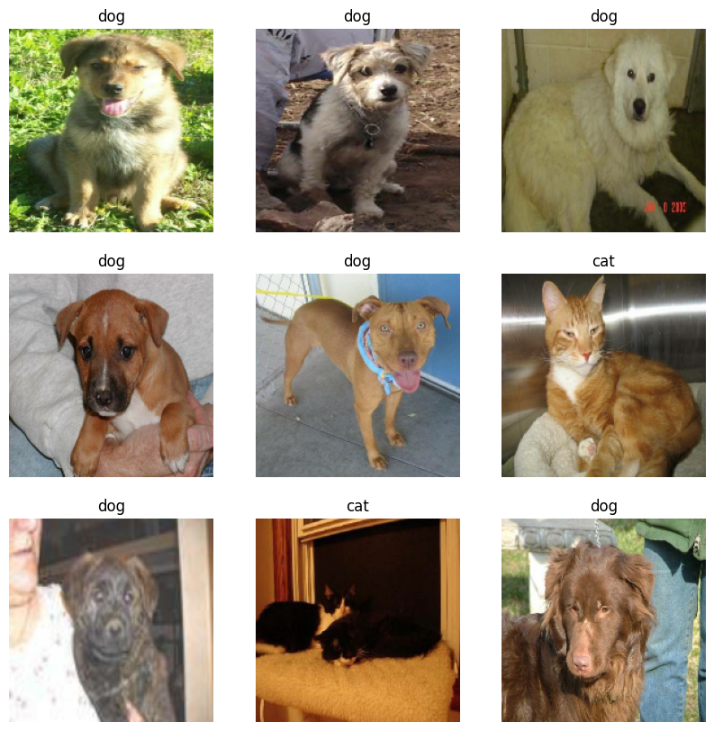

```python
import matplotlib.pyplot as plt

plt.figure(figsize=(10, 10))
for images, labels in train_dataset.take(1):
  for i in range(9):
    ax = plt.subplot(3, 3, i + 1)
    plt.imshow(images[i].numpy().astype("uint8"))
    plt.title(train_class_names[labels[i]])
    plt.axis("off")
```

- This 9 images are randomly selected, with its corresponding class name.

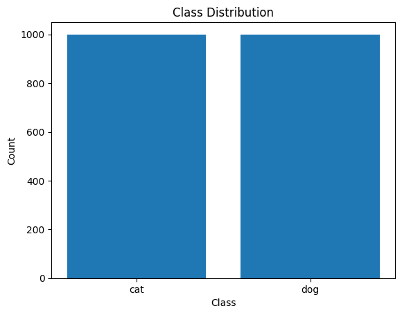

```python
import matplotlib.pyplot as plt

# Function to plot class distribution
def plot_class_distribution(dataset):
    class_names = dataset.class_names
    class_counts = [0] * len(class_names)
    for images, labels in dataset:
        for label in labels:
            class_counts[label.numpy()] += 1
    plt.bar(class_names, class_counts)
    plt.xlabel('Class')
    plt.ylabel('Count')
    plt.title('Class Distribution')
    plt.show()

# Plot class distribution for train_dataset
plot_class_distribution(train_dataset)
```

- This plot shows the two class "Dog" and "Cat" distribution which is similar for both classes(1000), as we load the dataset.

### **3. Train two networks**

#### **i. Neural Network with Custom Layers**

```python
# Define the model
inputs = layers.Input(shape=(180, 180, 3))
x = layers.Rescaling(1./255)(inputs)
x = layers.Conv2D(filters=64, kernel_size=3, activation="relu")(x)
x = layers.MaxPooling2D(pool_size=2)(x)
x = layers.Conv2D(filters=128, kernel_size=3, activation="relu")(x)
x = layers.MaxPooling2D(pool_size=2)(x)
x = layers.Conv2D(filters=256, kernel_size=3, activation="relu")(x)
x = layers.MaxPooling2D(pool_size=2)(x)
x = layers.Conv2D(filters=256, kernel_size=3, activation="relu")(x)
x = layers.MaxPooling2D(pool_size=2)(x)
x = layers.Flatten()(x)
outputs = layers.Dense(1, activation="sigmoid")(x)

# Create the model
model = keras.Model(inputs=inputs, outputs=outputs)
```

```python
model.summary()
```

[output not shown]

**In this custom model:**

- The input layer receives data with a shape of (180, 180, 3), where 180x180 represents the height and width of the input image, and 3 represents the number of channels (RGB).
- The rescaling layer scales the input data by dividing each pixel value by 255 to ensure it falls in the range [0, 1].
- The convolutional layer-1 applies 64 filters of size 3x3 to the input data, resulting in an output tensor with a shape of (178, 178, 64).
- Here, Total trainable parameter = (Size of Filter * Size of Filter * Number of Input Channels + bias) * Number of Filters

Total Trainable Parameters = (3 * 3 * 3 + 1) * 64 = (27 + 1) * 64 = 1792

- The max pooling layer reduces the spatial dimensions of the input tensor by a factor of 2 along both the height and width dimensions, resulting in an output tensor with a shape of (89, 89, 64).
- The same layers such as `conv2d` and `max_pooling` are added 3 more times with different parameters.
- After the all layers there are total 981,633 parameters and all are trainable

```python
# Model Compilation
model.compile(loss="binary_crossentropy",
              optimizer="rmsprop",
              metrics=["accuracy"])
```

```python
# Fit the Model
callbacks = [
    keras.callbacks.ModelCheckpoint(
        filepath="./model/convnet_from_scratch.keras",
        save_best_only=True,
        monitor="val_loss")
]
history = model.fit(
    train_dataset,
    epochs=30,
    validation_data=validation_dataset,
    callbacks=callbacks)
```

#### **Plot the training and validation loss and accuracy for Custom Model**

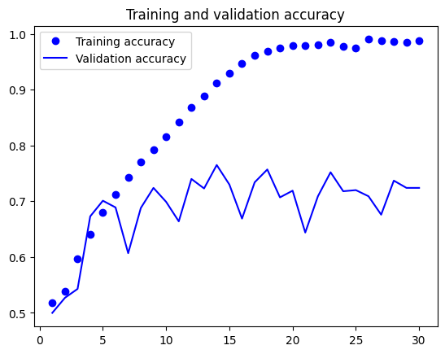

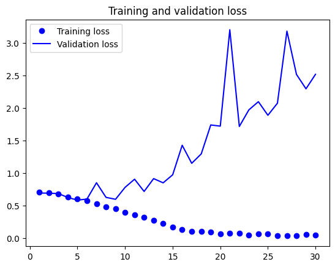

```python
accuracy = history.history["accuracy"]
val_accuracy = history.history["val_accuracy"]
loss = history.history["loss"]
val_loss = history.history["val_loss"]
epochs = range(1, len(accuracy) + 1)
plt.plot(epochs, accuracy, "bo", label="Training accuracy")
plt.plot(epochs, val_accuracy, "b", label="Validation accuracy")
plt.title("Training and validation accuracy")
plt.legend()
plt.figure()
plt.plot(epochs, loss, "bo", label="Training loss")
plt.plot(epochs, val_loss, "b", label="Validation loss")
plt.title("Training and validation loss")
plt.legend()
```

- When we look at the training loss, it decreases consistently with each training iteration until it reaches its minimum value. However, when we examine the validation loss, which represents how well our model performs on unseen data, it started increased after some epoch.
- Initially, the validation loss decreases steadily until around epoch 6. After that, it suddenly increases before dropping again at around a validation loss value of `0.5947 at epoch 9`. The lowest validation loss occurs at epoch 9. However, after that point, the validation loss begins to rise again. This indicates that our model is starting to overfit the data - it's getting really good at memorizing the training examples, but it's not getting better at generalizing to new, unseen examples.
- **In conclusion,** for our first model, the best weights are those obtained at `epoch 9` because they correspond to the lowest validation loss.

#### **Evaluate on the test dataset**

```python
test_model = keras.models.load_model("./model/convnet_from_scratch.keras")
```

```python
test_loss, test_acc = test_model.evaluate(test_dataset)
print(f"Test accuracy: {test_acc:.3f}")
```

```
Test accuracy: 0.702
```

#### **ii. Fine-Tune VGG16 (pre-trained on imagenet)**

- Pre-Trained model on Imagenet

```python
conv_base = keras.applications.vgg16.VGG16(
    weights="imagenet",
    include_top=False,
    input_shape=(180,180,3))
```

```python
conv_base.summary()
```

[output not shown]

**VGG16 model:**

Total Trainable Parameters = (3 * 3 * 3 + 1) * 64 = (27 + 1) * 64 = 1792

- The max pooling layer reduces the spatial dimensions of the input tensor by a factor of 2 along both the height and width dimensions, resulting in an output tensor with a shape of (90, 90, 64).
- The same layers such as `conv2d` and `max_pooling` are added 13 and 5 times respectively with different parameters.
- After the all layers there are total 14,714,688 parameters and all are trainable

**Here we define a new dense neural networks, of only two trainable layers.**

```python
inputs = keras.Input(shape=(180, 180, 3))
x = keras.applications.vgg16.preprocess_input(inputs)
x = conv_base(x)
x = layers.Flatten()(x)
x = layers.Dense(256)(x)
x = layers.Dropout(0.5)(x)
outputs = layers.Dense(1, activation="sigmoid")(x)
model_vgg = keras.Model(inputs,outputs)
```

**Freezing all layers until the fourth from the last**

```python
conv_base.trainable = True
for layer in conv_base.layers[:-4]:
    layer.trainable=False
```

```python
conv_base.summary()
```

[output not shown]

- After freezing the all layers except from the last four, the parameters are as below:
1. Total params: 14,714,688
2. Trainable params: 7,079,424
3. Non-trainable params: 7,635,264
- Now, we will fit our model on this trainable parameters

```python
# VGG Model Compilation
model_vgg.compile(loss="binary_crossentropy",
              optimizer=keras.optimizers.RMSprop(learning_rate=1e-5),
              metrics=["accuracy"])
```

```python
# Fit the Model and Save the Output
callbacks2 = [
    keras.callbacks.ModelCheckpoint(
        filepath="./model/fine_tuning.keras",
        save_best_only=True,
        monitor="val_loss")
]
history2 = model_vgg.fit(
    train_dataset,
    epochs=30,
    validation_data=validation_dataset,
    callbacks=callbacks2)
```

#### **Plot the training and validation loss and accuracy for VGG16**

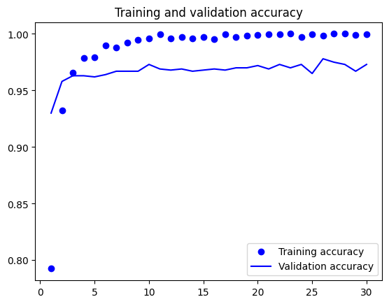

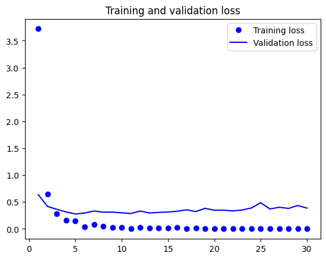

```python
acc = history2.history["accuracy"]
val_acc = history2.history["val_accuracy"]
loss = history2.history["loss"]
val_loss = history2.history["val_loss"]
epochs = range(1, len(acc) + 1)
plt.plot(epochs, acc, "bo", label="Training accuracy")
plt.plot(epochs, val_acc, "b", label="Validation accuracy")
plt.title("Training and validation accuracy")
plt.legend()
plt.figure()
plt.plot(epochs, loss, "bo", label="Training loss")
plt.plot(epochs, val_loss, "b", label="Validation loss")
plt.title("Training and validation loss")
plt.legend()
plt.show()
```

1. From the above graph of validation & training accuracy, the training accuracy keeps improving after every epoch but the validation accuracy plateaus at value 0.97 from around 11 epoch, this is the indication of overfitting.
2. From the above graph of validation & training accuracy, the training loss is keep reducing to nearly 0 value but, the validation loss make lowest validation loss = 0.2862 at epoch = 11 and then after shows slight increase after every epoch. So, this is also the indication of overfitting.

### **4. Model Evaluation on the test set with the best model choosen**

```python
# Load the Model output
best_model = keras.models.load_model("./model/fine_tuning.keras")
```

#### **i. Accuracy**

```python
# Checking the accuracy on the test set
test_loss, test_acc = best_model.evaluate(test_dataset)
print(f"Test accuracy: {test_acc:.3f}")
```

```
Test accuracy: 0.966
```

- The accuracy for above VGG16 model is 96.6% on the test set.

```python
from sklearn.metrics import confusion_matrix, classification_report, precision_recall_curve
import matplotlib.pyplot as plt
import numpy as np

# Predict labels on test dataset
predictions = best_model.predict(test_dataset)
predicted_labels = np.argmax(predictions, axis=1)

# True labels
true_labels = np.concatenate([y for x, y in test_dataset], axis=0)
```

#### **ii. Confusion Matrix**

```python
# Confusion Matrix
cm = confusion_matrix(true_labels, predicted_labels)
print("Confusion Matrix:")
print(cm)
```

```
Confusion Matrix:
[[1000    0]
 [1000    0]]
```

**The confusion matrix represent:**

1. True Positives (TP): The number of instances correctly predicted as class 0 (cat) is 1000.
2. False Negatives (FN): The number of instances incorrectly predicted as class 1 (dog) when they are actually class 0 (cat) is 0.
3. False Positives (FP): The number of instances incorrectly predicted as class 0 (cat) when they are actually class 1 (dog) is 1000.
4. True Negatives (TN): The number of instances correctly predicted as class 1 (dog) is 0.

#### **iii. Precision, Recall and F1-Score**

```python
# Classification report
class_report = classification_report(true_labels, predicted_labels, zero_division=1)
print("\n Classification Report:")
print(class_report)
```

```
 Classification Report:
              precision    recall  f1-score   support

           0       0.50      1.00      0.67      1000
           1       1.00      0.00      0.00      1000

    accuracy                           0.50      2000
   macro avg       0.75      0.50      0.33      2000
weighted avg       0.75      0.50      0.33      2000
```

- Precision: Precision is a measure of the accuracy of the positive predictions. In this report:
1. For class 0, the precision is 0.50, indicating that when the model predicts an instance as class 0, it is correct 50% of the time.
2. For class 1, the precision is 1.00, implying that when the model predicts an instance as class 1, it is correct 100% of the time.
- Recall: Recall is a measure of the completeness of the positive predictions. In this report:
1. For class 0, the recall is 1.00, indicating that the model correctly identifies all instances of class 0.
2. For class 1, the recall is 0.00, suggesting that the model fails to identify any instances of class 1.
- F1-score: The F1-score is the harmonic mean of precision and recall, providing a balance between the two metrics. In this report:
1. For class 0, the F1-score is 0.67, representing a balance between precision and recall for class 0.
2. For class 1, the F1-score is 0.00, indicating poor performance in terms of precision and recall for class 1.

#### **iv. Precision Recall Curve**

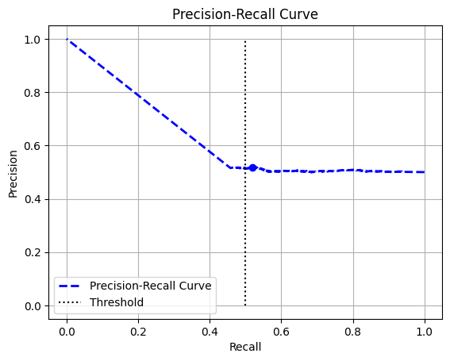

```python
from sklearn.metrics import precision_recall_curve
import matplotlib.pyplot as plt

# Calculate precision and recall values
precision, recall, thresholds = precision_recall_curve(true_labels, predictions)

# Define the threshold
threshold = 0.5  # Set your desired threshold value

# Plot precision-recall curve
plt.plot(recall, precision, 'b--', label='Precision-Recall Curve', linewidth=2)

# Plot threshold line
plt.vlines(threshold, 0, 1.0, 'k', 'dotted', label='Threshold')

# Mark the point corresponding to the threshold
idx = (thresholds >= threshold).argmax()
plt.plot(recall[idx], precision[idx], 'bo')

# Set plot properties
plt.xlabel('Recall')
plt.ylabel('Precision')
plt.title('Precision-Recall Curve')
plt.legend(loc='lower left')
plt.grid(True)
plt.show()
```

#### **v. Explore specific examples in which the model failed to predict correctly.**

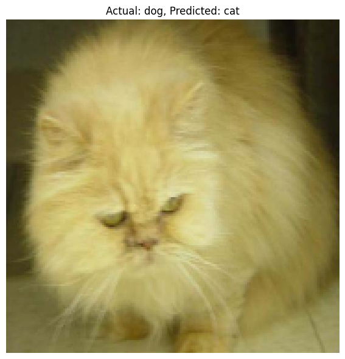

```
Predicted Probabilities:
cat: 1.0000
```

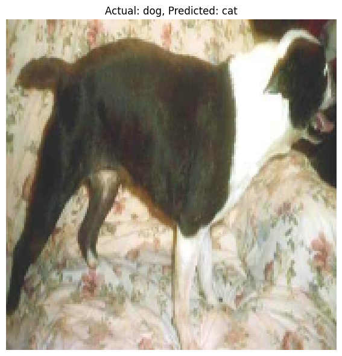

```
Predicted Probabilities:
cat: 1.0000
```

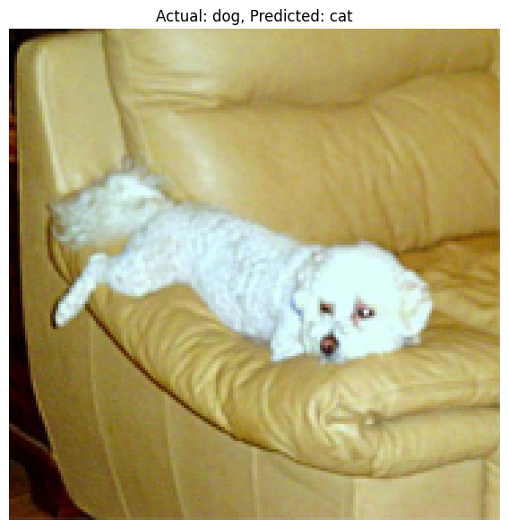

```
Predicted Probabilities:
cat: 0.0000
```

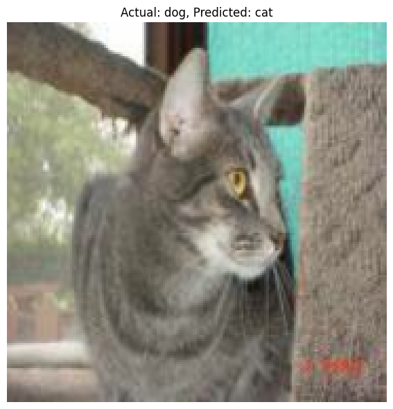

```
Predicted Probabilities:
cat: 0.0000
```

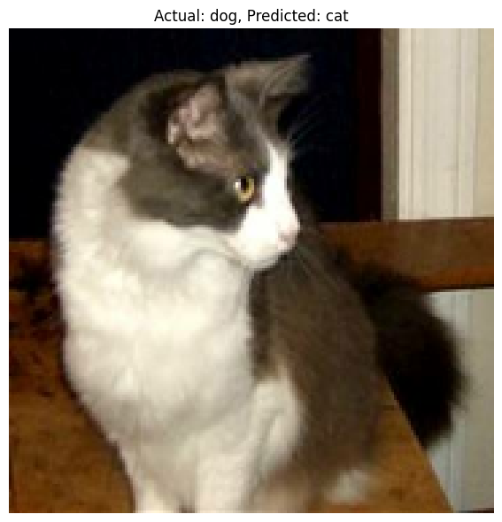

```
Predicted Probabilities:
cat: 1.0000
```

```python
misclassified_index = np.where(predicted_labels != true_labels)[0]

for idx, index in enumerate(misclassified_index[:5]):  # Display first 5 misclassified images
    # Getting the image batch after that image
    for images, _ in test_dataset.skip(index).take(1):
        img = images[0].numpy().astype('uint8')

    # Getting the true and predicted classes
    true_class_name = train_class_names[true_labels[index]]
    predicted_class_name = train_class_names[predicted_labels[index]]

    # Getting the predicted probabilities for each class
    predicted_probabilities = predictions[index]

    # Displaying the misclassified image
    plt.figure(figsize=(6, 6))
    plt.imshow(img)
    plt.title(f'Actual: {true_class_name}, Predicted: {predicted_class_name}', fontsize=12)
    plt.axis('off')
    plt.tight_layout()
    plt.show()

    # Displaying predicted probabilities for each class
    print("Predicted Probabilities:")
    for i, prob in enumerate(predicted_probabilities):
        class_name = train_class_names[i]
        print(f"{class_name}: {prob:.4f}")
```

- In the second and third image the model predicting wrongly as actual images are for dogs and model is predicting as a cat.

### **5. Conclusion**

**2. VGG16 Model**

- In training the VGG16 model we first load the pre trained VGG16 model on Imagenet data and then we freeze the all layers exceptr the last 4 layers. Then, we trained the model on the trainable parameters.
- The accuracy for above VGG16 model is 96.6% on the test set.
1. From the above graph of validation & training accuracy, the training accuracy keeps improving after every epoch but the validation accuracy plateaus at value 0.97 from around 11 epoch, this is the indication of overfitting.
2. From the above graph of validation & training accuracy, the training loss is keep reducing to nearly 0 value but, the validation loss make lowest validation loss = 0.2862 at epoch = 11 and then after shows slight increase after every epoch. So, this is also the indication of overfitting.